# Manejo de datos

Curso: Introducción a Ciencia de Datos

Autores/as

Dr. Gustavo Giménez

Mg. Ana Haique

Fecha de publicación

12 de agosto de 2026

# Importación (Episodio II)

[figure not shown]

Librerías de tidyverse

## Funciones `read_*` en `tidyverse`

### Archivos Delimitados

- `read_csv()`: Comas (`,`)
- `read_csv2()`: Punto y coma (`;`)
- `read_tsv()`: Tabulaciones (`\t`)
- `read_delim()`: Delimitador a elección

### Ancho Fijo y Espacios

- `read_fwf()`: Ancho fijo (*Fixed-width*)
- `read_table()`: Espacios en blanco

## Funciones `read_*` en estructura y texto

### Estructuras y Logs

- `read_rds()`: Formato nativo R (`.rds`)
- `read_log()`: Logs de servidores web

### Texto Plano

- `read_lines()`: Lee línea por línea
- `read_file()`: Lee el archivo completo en un string

```r
# Importar un CSV con formato hispano (decimales con coma)
datos <- read_csv2("datos_ventas.csv")

# Importar con un delimitador arbitrario (ej. barra vertical)
datos_custom <- read_delim("exportacion.txt", delim = "|")

# Cargar un objeto nativo de R previamente guardado
modelo <- read_rds("modelo_entrenado.rds")
```

## Importación de Archivos Comprimidos

Las funciones `read_*` de `readr` (en `tidyverse`) detectan y descomprimen automáticamente en memoria los archivos al leerlos, sin necesidad de instalar paquetes adicionales ni desempacar en el disco duro.

**Formatos soportados de forma nativa:**

- **Gzip (`.gz`):** El estándar más habitual para comprimir datasets extensos.
- **Bzip2 (`.bz2`):** Ofrece mayor tasa de compresión.
- **XZ (`.xz`):** Alta compresión usada en servidores y repositorios.
- **ZIP (`.zip`):** Funciona directamente si el archivo contiene un único texto.

## Casos especiales (Archivos ZIP):

```r
# Si el .zip contiene un solo archivo:
library(tidyverse)
datos_zip <- read_csv("reporte_anual.zip")

# Si el .zip contiene múltiples archivos:
datos_zip_sub <- read_csv(
  unz("archivos.zip", "tabla_especifica.csv")
)
```

## Importación de Hojas de Cálculo con `readxl`

A diferencia de `readr`, el paquete **`readxl`** pertenece al ecosistema Tidyverse pero **debe cargarse explícitamente** con `library(readxl)`. Detecta automáticamente si el archivo es `.xls` o `.xlsx`.

**Funciones y Parámetros Clave:**

- **`excel_sheets()`**: Lista las hojas del libro sin cargar los datos.
- **`sheet`**: Especifica la hoja por nombre (`"Ventas"`) o posición (`2`).
- **`range`**: Lee un rango exacto de celdas (ej. `"B3:F20"`).
- **`na`**: Define cadenas que representan valores nulos (ej. `c("", "N/A", "-")`).
- **`col_types`**: Fuerza tipos de columna o omite (`"skip"`).
- **`skip`**: Omite un número de filas iniciales.

## Ejemplo de uso con `readxl`

```r
library(readxl)

# 1. Explorar nombres de hojas
excel_sheets("reporte_2026.xlsx")

# 2. Leer hoja específica por nombre
ventas <- read_excel("reporte_2026.xlsx", sheet = "Ventas")

# 3. Leer rango exacto y personalizar nulos
datos_sub <- read_excel(
  path = "reporte_2026.xlsx",
  sheet = 1,
  range = "B3:F25",
  na = c("", "N/A", "-"),
  col_types = c("text", "numeric", "date", "skip", "numeric")
)
```

## Leer con datos faltantes

En hojas de calculo se escriben con . a veces con espacios en blancos o ambos

```r
# Si los datos faltantes están marcados solo con un punto:
datos <- read_excel("tu_archivo.xlsx", na = ".")

# Recomendado: considerar tanto el punto como las celdas vacías como NA
datos <- read_excel("tu_archivo.xlsx", na = c(".", ""))
```

## Omisión de Filas Iniciales y Encabezados en `readxl`

Es común encontrar archivos de Excel con títulos, notas o metadatos en las primeras filas antes de la tabla principal. Utiliza el argumento **`skip`** para omitirlos:

**Parámetros clave:**

- **`skip = n`**: Saltea las primeras `n` filas del archivo.
- **`col_names = TRUE`**: Por defecto, toma la primera fila útil (post-salteo) como nombre de columnas.
- **`na = c(".", "")`**: Combina el salteo de filas con la conversión de caracteres a `NA`.

## Ejemplo con Código:

```r
# 1. Saltear las primeras 4 filas de metadatos/texto
datos <- read_excel("reporte_ventas.xlsx", skip = 4)

# 2. Saltear filas e indicar que el punto "." es dato faltante
datos_limpios <- read_excel(
  path = "reporte_ventas.xlsx",
  sheet = "Ventas_2026",
  skip = 4,
  na = c(".", "")
)
```

## Ejercitando

📁 **Datos_ejercicios:** `Datos_Morfometricos_final.xlsx` — Mediciones morfométricas de cabras y cabritos al nacer.

1. **Identificar hojas:** Inspeccionar la estructura del libro con la función adecuada.
2. **Importar datos:** Cargar los datos teniendo en cuenta los problemas que presenta cada uno.
3. **Estadística descriptiva:** Calcular $\bar{x}$ y $s$ según **tratamiento** y **sexo** (Hoja 2).
4. **Análisis gráfico:** Graficar la relación entre **altura** y **perímetro torácico**.
5. **Análisis gráfico:** Graficar la relación entre **altura** y **perímetro torácico**, considerando el sexo al nacer.

## Escribir un Excel

Realizar una operación opuesta a partir de un objeto exportar a un .xlsx.

Archivo de datos de R a .xlsx

```r
#Instalar el paquete writexl
#install.packages("writexl")
data(cars)
head(cars)
```

```
  speed dist
1     4    2
2     4   10
3     7    4
4     7   22
5     8   16
6     9   10
```

```r
writexl::write_xlsx(cars, path = "Datos/Ejemplo_datos/autos20.xlsx")
```

## Unir Hojas de Excel con `bind_cols()`

### Pasos del proceso:

> **Nota:** Ambas hojas deben tener exactamente el mismo número de filas y coincidir ordenadamente.

```r
# 1. Cargar paquetes y listar hojas
ruta_excel <- "reporte_ventas.xlsx"
hojas <- excel_sheets(ruta_excel)

# 2. Cargar cada una por separado (solo 2 hojas)
hoja_1 <- read_excel(path = ruta_excel, sheet = hojas[1])
hoja_2 <- read_excel(path = ruta_excel, sheet = hojas[2])

# 3. Unir en un solo tibble con bind_cols
datos_completos <- bind_cols(hoja_1, hoja_2)

# Visualizar resultado
print(datos_completos)
```

## Combinar Datasets: `bind_cols()` vs `bind_rows()`

### Diferencias Clave:

- **`bind_cols()` (Unión Horizontal):**
  - Junta columnas de dos o más tablas de lado a lado.
  - **Requisito:** Mismo número de filas en ambas tablas.
- **`bind_rows()` (Unión Vertical):**
  - Apila registros (filas) uno debajo del otro.
  - **Requisito:** Nombres de columnas coincidentes (si una tabla no tiene una columna, se rellena con `NA`).

## Pegado de tablas

```r
# 1. Unión Horizontal (Añadir Columnas)
# Junta df1 y df2 a lo ancho
datos_ancho <- bind_cols(df1, df2)

# 2. Unión Vertical (Añadir Filas / Apilar)
# Coloca las filas de df2 debajo de df1
datos_largo <- bind_rows(df1, df2)

# Ejemplo apilando indicando el origen:
datos_apilados <- bind_rows(
  "Hoja 1" = df1,
  "Hoja 2" = df2,
  .id = "origen"
)
```

# Otros tipos de ingresos de datos

## Ingresar datos manualmente con tibble

```r
library(tibble)
# Crear tibble definiendo vectores de columna
datos_col <- tibble(
  id = 1:3,
  cliente = c("Ana", "Carlos", "Beatriz"),
  ventas = c(1500, 2300, 1800),

  # Referencia a la variable 'ventas' creada arriba
  comision = ventas * 0.10,

  # Reciclaje automático de valor único
  region = "Sur"
)

print(datos_col)
```

```
# A tibble: 3 × 5
     id cliente ventas comision region
  <int> <chr>    <dbl>    <dbl> <chr>
1     1 Ana       1500      150 Sur
2     2 Carlos    2300      230 Sur
3     3 Beatriz   1800      180 Sur
```

## Ingreso Fila por Fila con tribble

Características de tribble(): *Transposed Tibble*: Diseñado para escribir tablas pequeñas de forma visual en el código. Encabezados con Tilde (~): Las columnas se definen antecediendo una tilde (ej. ~columna). Lectura Fila a Fila: Los datos se ingresan de izquierda a derecha separados por comas.

```r
# Crear tibble orientado a filas (legible y tabulado)
datos_filas <- tribble(
  ~id, ~cliente,  ~ventas, ~categoria,
    1, "Ana",     1500,    "Premium",
    2, "Carlos",  2300,    "Estándar",
    3, "Beatriz", 1800,    "Premium"
)

print(datos_filas)
```

```
# A tibble: 3 × 4
     id cliente ventas categoria
  <dbl> <chr>    <dbl> <chr>
1     1 Ana       1500 Premium
2     2 Carlos    2300 Estándar
3     3 Beatriz   1800 Premium
```

## Importar múltiples archivos

A veces es necesario importar varios archivos al mismo tiempo

```r
library(readr)
#1.Listar los archivos
list.files("Datos/Ejemplo_datos/datos_multiple/", pattern = "\\.csv$")
```

```
[1] "clientes.csv"   "envios.csv"     "inventario.csv" "ventas.csv"
```

```r
#Lee e importa todos los archivos csv a una lista
todos_data_frames <- lapply(list.files("Datos/Ejemplo_datos/datos_multiple/", pattern = "*.csv", full.names = TRUE), read_csv)
todos_data_frames
```

```
[[1]]
# A tibble: 3 × 3
     id nombre  ciudad
  <dbl> <chr>   <chr>
1     1 Ana     Mendoza
2     2 Carlos  Rosario
3     3 Beatriz Cordoba

[[2]]
# A tibble: 3 × 3
     id transporte       estado
  <dbl> <chr>            <chr>
1     1 Andreani         Entregado
2     2 OCA              En camino
3     3 Correo Argentino Pendiente

[[3]]
# A tibble: 3 × 3
  producto stock categoria
  <chr>    <dbl> <chr>
1 Laptop      15 Cómputo
2 Mouse      120 Periféricos
3 Teclado     45 Periféricos

[[4]]
# A tibble: 3 × 3
     id producto monto
  <dbl> <chr>    <dbl>
1     1 Laptop    1200
2     2 Mouse       25
3     3 Teclado     45
```

## Ejercitando (II)

📁 **Conjunto de datos:** `precios_manzana_pera_desde17_corpat.csv.gz` — Registro de precios de Manzanas y Peras (MCBA, 2017–2026).

1. **Compresión (.gz):** ¿Qué tipo de archivo es y qué ventajas presenta respecto a un `.csv` tradicional?
2. **Importación y estructura:** Importar los datos. ¿Qué función de `{readr}` se usa, qué dimensiones tiene el *tibble* y qué tipos de datos contiene?
3. **Formato de fechas:** Transformar la columna `dia` a formato de fecha utilizando el paquete `{lubridate}`.
4. **Extracción de componentes:** Obtener variables para **año**, **mes (con nombre)** y **semana del año**.
5. **Filtrado y visualización:** Filtrar la especie `"Manzana"`, calcular la media del `MOPK` por año/mes y graficar. ¿Qué patrón o dato extraño se observa?

# Bases de datos

[figure not shown]

Librerías de tidyverse

## ¿Qué es una Base de Datos?

### Una analogía sencilla

Podemos concebirla como **gran biblioteca digital centralizada**:

- En lugar de tener archivos Excel desparramados en la computadora, la información está ordenada en **tablas**.
- Cada tabla es como una planilla (con columnas para variables y filas para registros).
- El sistema garantiza que los datos estén **protegidos**, **actualizados** y **disponibles** para muchas personas al mismo tiempo.

**Nota💡 La diferencia con Excel**

Un archivo `.xlsx` esta en la computadora y tiene un límite estricto de filas. Una **Base de Datos** vive en un servidor, maneja millones de datos y no se “cuelga”.

### ¿Por qué las usamos en Ciencia de Datos?

- **Estructura limpia:** Evita datos duplicados o inconsistentes.
- **Velocidad de búsqueda:** Utiliza **índices** (como el índice de un libro) para encontrar un registro en milisegundos entre millones de filas.
- **Fuente única de verdad:** Todo el equipo analiza los mismos datos reales sin andar enviándose versiones (`datos_final_v2.csv`).

## Acceso a Bases de Datos en R

### ¿Por qué conectarse directamente?

- **Autonomía:** Evita depender de descargas intermedias de archivos `.csv`.
- **Eficiencia:** Consulta los datos necesarios en tiempo real directamente en el servidor.
- **Estándar:** Interactúa mediante SQL usando tus sintaxis habituales de `dplyr`.

**Nota🛠️ Herramientas clave**

- **`DBI`**: Interfaz de bajo nivel que gestiona la conexión y ejecuta consultas SQL.
- **`dbplyr`**: Interfaz de alto nivel que traduce código `dplyr` a consultas SQL.

### Paquetes requeridos

```r
library(DBI)
library(dbplyr)
library(tidyverse)
```

**Tip**

💡 Filosofía

No necesitas ser un experto en SQL para empezar: {dbplyr} traduce tus operaciones de manipulación de datos automáticamente.

## Conexión a una Base de Datos

Arquitectura de Conexión

DBI: Proporciona las funciones genéricas de control (dbConnect(), etc.).

Driver específico: Paquete según el motor (ej: RPostgres o RMariaDB).

odbc: Protocolo alternativo universal si no hay un driver nativo.

**Advertencia**

🔑 Credenciales

Los parámetros de conexión (host, puerto, usuario, contraseña) te los proporcionará el administrador de la base de datos (DBA).

Ejemplo de Conexión en R R

```r
# Ejemplo 1: Conexión a MariaDB
con <- DBI::dbConnect(
  RMariaDB::MariaDB(),
  username = "foo"
)

# Ejemplo 2: Conexión a PostgreSQL en servidor remoto
con <- DBI::dbConnect(
  RPostgres::Postgres(),
  hostname = "databases.mycompany.com",
  port = 1234
)
```

## Paso 1:Conexión a la base

Cargar paquetes y conectar a la base de datos

Usamos DBI para crear el canal de comunicación con la base SQLite y dbplyr para trabajar con sintaxis R sobre las tablas remotas. R.

```r
library(DBI)
library(RSQLite)
library(dplyr)
library(dbplyr)

# Establecer la conexión con el archivo de base de datos
con1 <- dbConnect(
  RSQLite::SQLite(),
  "Datos/Ejemplo_datos/diamonds_relacional.sqlite"
  )
```

## Paso 2: inspeccionar tablas

Antes de realizar la consulta, verificamos qué tablas existen dentro de la base de datos y qué columnas tiene cada una.

```r
# Listar todas las tablas en la base de datos
dbListTables(con1)
```

```
[1] "claridades" "cortes"     "diamantes"
```

```r
# Resultado esperado: "claridades" "cortes" "diamantes"

# Ver las columnas de una tabla específica
dbListFields(con1, "diamantes")
```

```
[1] "id_diamante" "carat"       "color"       "price"       "x"
[6] "y"           "z"           "id_corte"    "id_claridad"
```

```r
# (Opcional) Ver la estructura general mediante una consulta SQL rápida
dbGetQuery(con1, "SELECT COUNT(*) AS total_filas FROM diamantes")
```

```
  total_filas
1       53940
```

## Paso 3: Crear referencias de tabla con dbplyr

La función tbl() crea un objeto lazy table. No carga los 50.000 datos en la memoria RAM de R, sino que establece un enlace hacia la tabla en disco.

```r
# Crear referencias virtuales a cada tabla
diamantes_db <- tbl(con1, "diamantes")
cortes_db    <- tbl(con1, "cortes")
claridades_db <- tbl(con1, "claridades")

# Si imprimes la variable, muestra las primeras 10 filas sin traer toda la base
print(diamantes_db)
```

```
# A query:  ?? x 9
# Database: sqlite 3.53.3 [C:\Users\Posgrado\Documents\Clase_4\Datos\Ejemplo_datos\diamonds_relacional.sqlite]
   id_diamante carat color price     x     y     z id_corte id_claridad
         <int> <dbl> <chr> <int> <dbl> <dbl> <dbl>    <int>       <int>
 1           1  0.23 E       326  3.95  3.98  2.43        1           1
 2           2  0.21 E       326  3.89  3.84  2.31        2           2
 3           3  0.23 E       327  4.05  4.07  2.31        3           3
 4           4  0.29 I       334  4.2   4.23  2.63        2           4
 5           5  0.31 J       335  4.34  4.35  2.75        3           1
 6           6  0.24 J       336  3.94  3.96  2.48        4           5
 7           7  0.24 I       336  3.95  3.98  2.47        4           6
 8           8  0.26 H       337  4.07  4.11  2.53        4           2
 9           9  0.22 E       337  3.87  3.78  2.49        5           4
10          10  0.23 H       338  4     4.05  2.39        4           3
# ℹ more rows
```

## Paso 4: Manipular los datos con sintaxis dplyr

Se usan los verbos habituales de {dplyr} (filter, group_by, summarise, left_join, mutate). Todo se procesará dentro del motor SQLite.

```r
# Unir las 3 tablas relacionales y calcular el precio medio por tipo de corte
resumen_cortes <- diamantes_db %>%
  left_join(cortes_db, by = "id_corte") %>%
  left_join(claridades_db, by = "id_claridad") %>%
  filter(price > 1000) %>%
  group_by(corte) %>%
  summarise(
    cantidad = n(),
    precio_promedio = mean(price, na.rm = TRUE),
    quilates_max = max(carat, na.rm = TRUE)
  ) %>%
  arrange(desc(precio_promedio))
```

## Paso 6: Traer el resultado final a R con collect()

Hasta este punto, nada se ha descargado a R. Cuando se requiera guardar el resultado procesado como un data.frame local, se ejecut collect():

```r
# Descargar el resultado procesado a la memoria RAM de R
datos_locales <- resumen_cortes %>% collect()

# Verificar la clase del objeto procesado
class(datos_locales) # "tbl_df" "tbl" "data.frame"
```

```
[1] "tbl_df"     "tbl"        "data.frame"
```

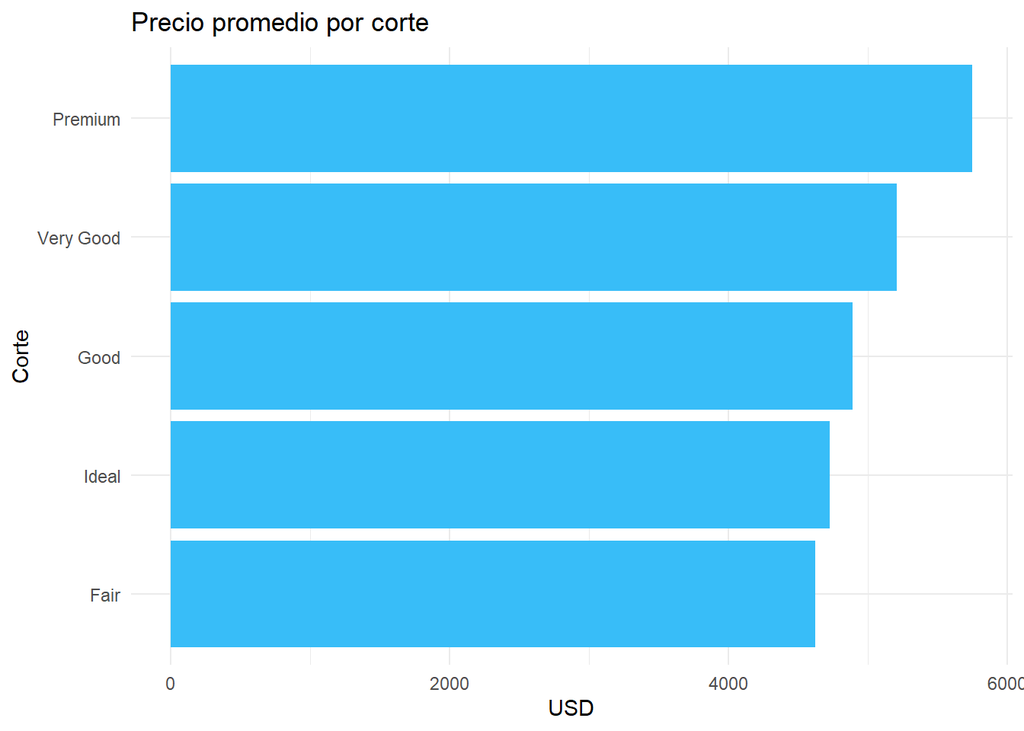

```r
### Graficar el resultado local
library(ggplot2)

ggplot(datos_locales, aes(x = reorder(corte, precio_promedio), y = precio_promedio)) +
  geom_col(fill = "#38bdf8") +
  coord_flip() +
  labs(title = "Precio promedio por corte", x = "Corte", y = "USD") +
  theme_minimal()
```

## Ver la sintaxis que de sql

```r
# Ver la consulta SQL en texto plano que se enviará al servidor
resumen_cortes %>% show_query()
```

```
<SQL>
SELECT
  `corte`,
  COUNT(*) AS `cantidad`,
  AVG(`price`) AS `precio_promedio`,
  MAX(`carat`) AS `quilates_max`
FROM (
  SELECT `diamantes`.*, `corte`, `claridad`
  FROM `diamantes`
  LEFT JOIN `cortes`
    ON (`diamantes`.`id_corte` = `cortes`.`id_corte`)
  LEFT JOIN `claridades`
    ON (`diamantes`.`id_claridad` = `claridades`.`id_claridad`)
  WHERE (`diamantes`.`price` > 1000.0)
) AS `q01`
GROUP BY `corte`
ORDER BY `precio_promedio` DESC
```

```r
library(dm)

# Carga las tablas, PK y FK automáticamente desde el esquema de SQLite
modelo_dm <- dm_from_src(con1)

# Dibujar directamente
dm_draw(modelo_dm)
```

[output not shown]

## Desconectar de la base de daos

```r
dbDisconnect(con1)
```